# Day 29 - Tests

Spring 2023

[Dr. Jared Joseph](https://jnjoseph.com/)

Smith College

## Overview

### Timeline

- What is a Test?
- Automated Testing
- Tools for Testing

### Goal

To learn about and create automated tests for your package.

# What is a Test?

## A Test is …

Code to assure

the output you are getting

is the output you expect.

## You Already Run Tests

We are testing *constantly* while writing new code.

Often we write a line, try it, get an error, adapt, and try again.

This works great while you are working on something new.

Recall this loops forever …

```r
# make a print method for my "CoolClass" class
print.CoolClass = function(x){

  cat("B) You've got this!\n")
  print(x)

}

# test out new method
print(test_vec)
```

Yet this is fine…

```r
# make a print method for my "CoolClass" class
print.CoolClass = function(x){

  cat("B) You've got this!\n")
  cat(x)

}

# test out new method
print(test_vec)
```

## You Test While Writing Packages

You’ve (hopefully) also tested your package functions along the way.

This requires a few extra steps, but the process is the same.

Try, revise, try again …

Making Package Functions:

1. Write function.r
2. devtools::load_all()
3. Try it
4. Edit function.r
5. devtools::load_all()
6. Try again
7. etc.

## The Problem with Manual Tests

You’re only doing them now.

What happens when you change something later? Will you come back and make sure everything still works?

# Automated Testing

## The Role of Automated Testing

Say you create a function for your package that you will use as an intermediate step …

```r
test_vec = c(TRUE, FALSE, FALSE, TRUE, FALSE, FALSE, TRUE, FALSE)
```

Week 1

```r
my_func_1 = function(x){
  return(letters[x])
}

out_1 = my_func_1(test_vec)
out_1
```

```
 [1] "a" "d" "g" "i" "l" "o" "q" "t" "w" "y"
```

```r
my_func_2 = function(x){
  # test for vowels
  vowels = c("a", "e", "i", "o", "u") %in% x
  names(vowels) = c("a", "e", "i", "o", "u")

  return(vowels)
}

my_func_2(out_1)
```

```
    a     e     i     o     u
 TRUE FALSE  TRUE  TRUE FALSE
```

Week 6

```r
my_func_1 = function(x){
  return(LETTERS[x])
}

out_1 = my_func_1(test_vec)
out_1
```

```
 [1] "A" "D" "G" "I" "L" "O" "Q" "T" "W" "Y"
```

```r
my_func_2 = function(x){
  # test for vowels
  vowels = c("a", "e", "i", "o", "u") %in% x
  names(vowels) = c("a", "e", "i", "o", "u")

  return(vowels)
}

my_func_2(out_1)
```

```
    a     e     i     o     u
FALSE FALSE FALSE FALSE FALSE
```

## Sanity Checks

Even simple tests can prevent heartache.

A simple test for our above example would be something like: “If all of my results are false, I should probably look into that.”

We can code these gut checks into actual tests that will be run whenever we check our package.

A simple test

```r
# run my_func_2
out = my_func_2(out_1)
out
```

```
    a     e     i     o     u
FALSE FALSE FALSE FALSE FALSE
```

```r
if(sum(out) == 0){
  warning(
    "Something might be wrong with `my_func_2`.
     All results were false.")
}
```

# Tools for Testing

## Where Tests Live

`tests` is an “optional” directory which contains unit-tests for your code.

Unit tests essentially run your code and check the results against pre-determined outputs.

If you change something and one of these known outputs change, you know something broke.

```
R Project Name
```

```r
.
├── R/
│   └── func1.R
├── man/
│   └── func1.Rd
├── inst/
│   ├── data/
│   │   └── example_data1.csv
│   └── other
├── vignettes/
│   └── v1.rmd
├── docs/
│   └── v1.html
├── tests/
│   └── testthat/
│       └── test-func1.R
├── NAMESPACE
├── DESCRIPTION
├── LICENSE
├── NEWS.md
├── README.Rmd
├── .gitignore
└── .Rbuildignore
```

## `testthat` Package

The `testthat` package integrates testing into the process of building your package.

Much like how `roxygen2` gives us helpers for documentation, `testthat` gives us helpers for tests.

You can use `usethis::use_test()` to create a test file for the currently open function.

If I have the `R/comma_split.R` function open, I can use `usethis::use_test()` to create a test template.

```r
usethis::use_test()
```

```r
✔ Setting active project to 'final-project-test-team'
✔ Adding 'testthat' to Suggests field in DESCRIPTION
✔ Setting Config/testthat/edition field in DESCRIPTION to '3'
✔ Creating 'tests/testthat/'
✔ Writing 'tests/testthat.R'
✔ Writing 'tests/testthat/test-comma_split.R'
• Modify 'tests/testthat/test-comma_split.R'
```

This creates a matching `tests/testthat/test-comma_split.R` file.

## Still Need to Make Tests Though

Much like help files, we have tools to scaffold for us, but we still need to build things ourselves.

Tests are just R code, but makes use of some specific functions.

Each of these functions is designed to compare the results of some code with a known answer.

Some tests you can run:

- `expect_equal()`
- `expect_error()`
- `expect_warning()`
- `expect_message()`
- `expect_s3_class()`
- `expect_true()`
- `expect_false()`

[Link: More here](https://testthat.r-lib.org/reference/)

## An Example Test

### Manual

```r
# run my_func_2
out = my_func_2(out_1)
out
```

```
    a     e     i     o     u
FALSE FALSE FALSE FALSE FALSE
```

```r
if(sum(out) == 0){
  warning(
    "Something might be wrong with `my_func_2`.
     All results were false.")
}
```

### `testthat`

```r
# assuming my_func_2 is in package
out = my_func_2(out_1)

# test
testthat::test_that("Is my_func_2 working?", {

  # I expect at least 1 true
  testthat::expect_true(any(out))
})
```

```
── Failure ('<text>:8'): Is my_func_2 working? ─────────────────────────────────
any(out) is not TRUE

`actual`:   FALSE
`expected`: TRUE
```

```
Error in `reporter$stop_if_needed()`:
! Test failed
```

*Note that when writing tests for a package, you don’t need `testthat::` for everything. R will load it when it goes to test things.*

## Now Automated

Your tests will now run every time you use `devtools::test()` or `devtools::check()` your package.

Most of the time, things will work fine!

However, if anything ever does break, you will have an early warning, and clear hints on where and why things broke.

A working test

```r
testthat::test_that("multiplication works", {
  testthat::expect_equal(2 * 2, 4)
})
```

```
Test passed 😀
```

Testing whole package

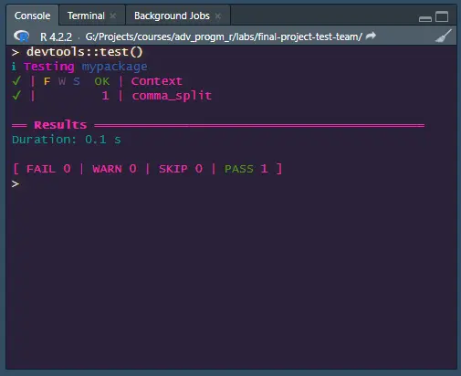

## Testing Tips

Much like examples, tests need to be simple, yet realistic

They must also be completely self-contained.

They do have access to and data you store in `inst/data` though.

Tests should:

- Be self-contained
- Test only one thing at a time
- Test the major functions in your package (aka have good coverage)
- Be well commented (you only look at them when something goes wrong!)

## Check Yourself

Your go-to tool for checking up on how your package is working is the `devtools::check()` function.

It will run all of your tests, and check some other basic milestones and see if your package is healthy.

You should check **often** to make sure you aren’t accumulating problems.

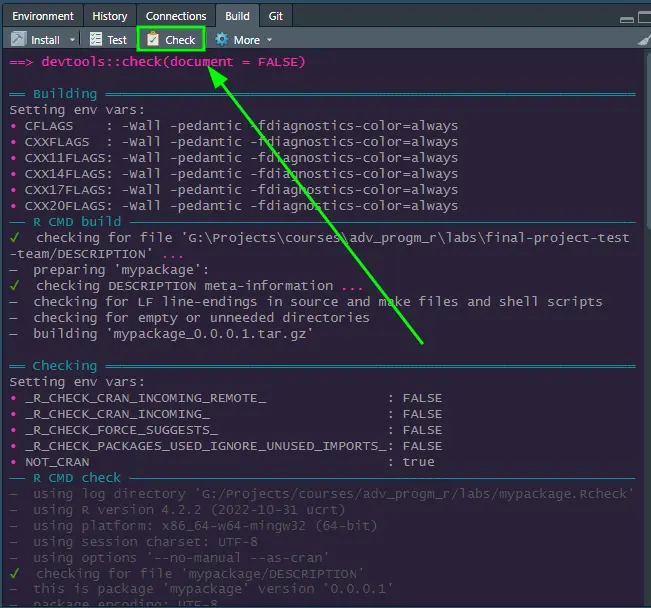

## An Error I Expect

If you have been using the `package::function()` syntax in your functions (as you should be doing), you will get an error when you now run `devtools::check()`

This is because we have not added those packages to the *dependancies* for our package yet.

To do so, simply run `usethis::use_package("PACKAGE NAME")`. This will add it to your description file.

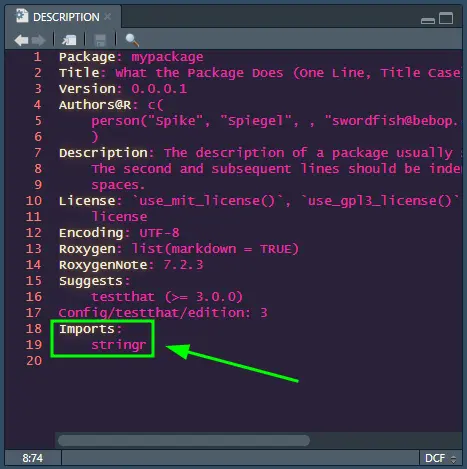

# Code-Along

## For Next Time

### Topic

Benchmarking

### To-Do

- Finish Worksheet
- READ: [23 Measuring performance](https://adv-r.hadley.nz/perf-measure.html)

SDS 270: Advanced Programming for Data Science